# Quantifing Quality of Exercise

Wei Ann Lim

24 July 2015

# Executive Summary

Using devices such as Jawbone Up, Nike FuelBand, and Fitbit it is now possible to collect a large amount of data about personal activity relatively inexpensively. One thing that people regularly do is quantify how much of a particular activity they do, but they rarely qualify that activity.

Data from accelerometers on the belt, forearm, arm, and dumbell of 6 participants were collected while they were performing barbell lifts correctly and incorrectly in 5 different ways. Accelerometers data are then labelled as A, B, C, D or E to represent the quality of lifts performed. The quality of the lifts associated with each rows of data are stored in the variable **classe**.

This write up describes how a model was built to allow prediction of the quality of barbell lift performed based on accelerometer data.

The data for building the model comes from http://groupware.les.inf.puc-rio.br/har, and they are available here https://d396qusza40orc.cloudfront.net/predmachlearn/pml-training.csv

# Building the model

## Data Preparation

Before building the model, Exploratory Data Analysis and data cleaning is done.

```r
names(train)
```

```
##   [1] "X"                        "user_name"
##   [3] "raw_timestamp_part_1"     "raw_timestamp_part_2"
##   [5] "cvtd_timestamp"           "new_window"
##   [7] "num_window"               "roll_belt"
##   [9] "pitch_belt"               "yaw_belt"
##  [11] "total_accel_belt"         "kurtosis_roll_belt"
##  [13] "kurtosis_picth_belt"      "kurtosis_yaw_belt"
##  [15] "skewness_roll_belt"       "skewness_roll_belt.1"
##  [17] "skewness_yaw_belt"        "max_roll_belt"
##  [19] "max_picth_belt"           "max_yaw_belt"
##  [21] "min_roll_belt"            "min_pitch_belt"
##  [23] "min_yaw_belt"             "amplitude_roll_belt"
##  [25] "amplitude_pitch_belt"     "amplitude_yaw_belt"
##  [27] "var_total_accel_belt"     "avg_roll_belt"
##  [29] "stddev_roll_belt"         "var_roll_belt"
```

[output cut: 65 more lines]

The first 7 variables, i.e. X, user_name, raw_timestamp_part_1, raw_timestamp_part_2, cvtd_timestamp, new_window, num_window, are not sensor data. They will be remove from the analysis.

```r
train <- train[, -(1:7)]
```

Now, let’s look at how complete each column of data is.

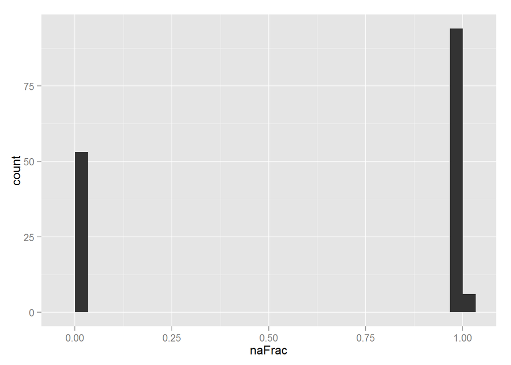

```r
# For each variable, calculate the percentage of NA values
naFrac <- apply(train, 2, function(x) {sum(is.na(x))/length(x)})
qplot(naFrac, geom = "histogram")
```

It was found that some variables consist of more than 90% NA values, while other variables have no NA values. Variables with more than 90% NA values, will not be useful for prediction, hence they will be removed from the dataset.

```r
# Keep Variables with less than 90% NA values
train <- train[, naFrac < 0.9]
```

Highly correlated variables are also removed from the analysis. High correlated variables are found using the **findCorrelation()** function.

First, find the correlation between each variables.

```r
corelation_mat <- cor(train[, -53]) # column 53 is where the "classe" variable is stored

# Set variable correlation with itself equal to 0
diag(corelation_mat) <- 0
```

Find variables with correlation > 0.75 and remove them.

```r
# Cut off variables with corelation > 0.75
# Use the **findCorrelation** function
highlyCor <- findCorrelation(corelation_mat, 0.75)

# create a data.frame where the highly correlated variables are removed
train_sub <- train[, -highlyCor]
```

After these variables are removed, a **Random Forest** model is built with the remaining variables.

## Random Forest

To estimate the test error, I used 5 fold cross validation. We set the parameters of the cross validation in the **trainControl()** function.

```r
cvCtrl <- trainControl(method = "cv", number = 5)
```

With the **trainControl()** setup, I will train the model.

```r
set.seed(2706)
rfFitCV <- train(classe ~ .,  data = train_sub, method = "rf", importance = TRUE, trControl = cvCtrl, allowParallel = TRUE)
rfFitCV
```

```
## Random Forest
##
## 19622 samples
##    32 predictor
##     5 classes: 'A', 'B', 'C', 'D', 'E'
##
## No pre-processing
## Resampling: Cross-Validated (5 fold)
##
## Summary of sample sizes: 15696, 15698, 15699, 15697, 15698
##
## Resampling results across tuning parameters:
##
##   mtry  Accuracy   Kappa      Accuracy SD  Kappa SD
##    2    0.9931711  0.9913613  0.001614780  0.002042900
##   17    0.9922535  0.9902007  0.001437659  0.001818857
##   32    0.9859855  0.9822715  0.001770845  0.002240119
##
## Accuracy was used to select the optimal model using  the largest value.
## The final value used for the model was mtry = 2.
```